# Demo: Multiple Regression

## 5 The Full Model: Price + Advertising + ShelveLoc

Combining both insights:

$$\widehat{\text{Sales}}_i = b_0 + b_1 \cdot \text{Price}_i
+ b_2 \cdot \text{Advertising}_i
+ b_3 \cdot \mathbf{1}_{\text{Good}}
+ b_4 \cdot \mathbf{1}_{\text{Medium}}$$

```r
tb <- mod_full %>%
  get_regression_table() %>%
  select(term, estimate) %>%
  gt()
```

**Show code: table formatting**

```r
tb %>%
  fmt_number(columns = estimate, decimals = 4) %>%
  tab_style(style = cell_fill(color = "#f5f0fa"),
            locations = cells_body(rows = str_detect(term, "ShelveLoc"))) %>%
  tab_style(style = cell_fill(color = "#fff0f0"),
            locations = cells_body(rows = term == "Price")) %>%
  tab_style(style = cell_fill(color = "#f0fff8"),
            locations = cells_body(rows = term == "Advertising")) %>%
  tab_options(table.font.size = "14px") %>%
  tab_header(
    paste0("Sales ~ Price + Advertising + ShelveLoc  |  adj. R² = ",
           round(summary(mod_full)$adj.r.squared, 3)),
    subtitle = "Purple = ShelveLoc | Red = Price | Green = Advertising"
  )
```

Sales ~ Price + Advertising + ShelveLoc | adj. R² = 0.605

Purple = ShelveLoc | Red = Price | Green = Advertising

| term | estimate |
| --- | --- |
| intercept | 11.4680 |
| Price | −0.0580 |
| Advertising | 0.1090 |
| ShelveLoc: Medium | 1.8290 |
| ShelveLoc: Good | 4.7760 |

**Live computation — ceteris paribus:**

```r
# Predicted Sales: Good shelf, Price = 120, Advertising = 10
predict(mod_full,
        newdata = data.frame(Price = 120, Advertising = 10, ShelveLoc = "Good"))
```

```
       1
10.38057
```

```r
# Manual — shows each term's contribution
b <- coef(mod_full)
b["(Intercept)"] +
  b["Price"]          * 120 +
  b["Advertising"]    * 10  +
  b["ShelveLocGood"]  * 1
```

```
(Intercept)
   10.38057
```

**Tip Instructor note — live computation**

Type this live. Then vary: - `ShelveLoc = "Bad"` → *how much does the shelf-location shift cost?* - `Advertising = 0` → *how much of the prediction came from advertising?*

This makes ceteris paribus tangible: change one input, hold all others fixed, see what happens.

## 6 Model Quality and Selection

### 6.1 Systematic comparison

```r
tb <- bind_rows(
  get_regression_summaries(mod_baseline)  %>% mutate(Model = "① Sales ~ Price",                     k = 2),
  get_regression_summaries(mod_adv)       %>% mutate(Model = "② + Advertising",                     k = 3),
  get_regression_summaries(mod_shelf)     %>% mutate(Model = "③ + ShelveLoc (parallel)",             k = 4),
  get_regression_summaries(mod_full)      %>% mutate(Model = "④ + Advertising + ShelveLoc",          k = 5),
  get_regression_summaries(mod_int_shelf) %>% mutate(Model = "⑤ + ShelveLoc × Price (interaction)", k = 6)
) %>%
  select(Model, k, r_squared, adj_r_squared, rmse) %>%
  gt()
```

**Show code: table formatting**

```r
tb %>%
  fmt_number(columns = c(r_squared, adj_r_squared, rmse), decimals = 4) %>%
  tab_style(style = cell_fill(color = "#f0fff0"),
            locations = cells_body(rows = 4)) %>%
  tab_style(style = cell_fill(color = "#fff8e1"),
            locations = cells_body(rows = 5)) %>%
  tab_options(table.font.size = "13px") %>%
  tab_header(
    "Model comparison across all specifications",
    subtitle = "Green = selected model ④ | Yellow = interaction (not warranted)"
  ) %>%
  tab_footnote("adj. R² penalises additional parameters — use it (not R²) to compare model sizes")
```

Model comparison across all specifications

Green = selected model ④ | Yellow = interaction (not warranted)

| Model | k | r_squared | adj_r_squared | rmse |
| --- | --- | --- | --- | --- |
| ① Sales ~ Price | 2 | 0.1980 | 0.1960 | 2.5260 |
| ② + Advertising | 3 | 0.2820 | 0.2780 | 2.3903 |
| ③ + ShelveLoc (parallel) | 4 | 0.5430 | 0.5390 | 1.9076 |
| ④ + Advertising + ShelveLoc | 5 | 0.6080 | 0.6050 | 1.7649 |
| ⑤ + ShelveLoc × Price (interaction) | 6 | 0.5440 | 0.5390 | 1.9038 |

adj. R² penalises additional parameters — use it (not R²) to compare model sizes

### 6.2 Adjusted R²

**R² always increases** when a regressor is added — even random noise marginally improves in-sample fit. **Adjusted R²** corrects for this:

$$\bar{R}^2 = 1 - \frac{n-1}{n-k} \cdot (1 - R^2)$$

where $k$ = number of parameters (including intercept). If a regressor adds less explanatory power than a random variable would on average, $\bar{R}^2$ decreases. Use $\bar{R}^2$ — not $R^2$ — when comparing models of different sizes.

### 6.3 OVB correction: the Price coefficient across specifications

```r
tb <- tibble(
  Model      = c("① Price only", "② + Advertising",
                 "③ + ShelveLoc", "④ + Both", "⑤ Interaction"),
  `b̂_Price`  = map_dbl(
    list(mod_baseline, mod_adv, mod_shelf, mod_full, mod_int_shelf),
    ~ coef(.x)["Price"]
  ),
  `adj. R²`  = map_dbl(
    list(mod_baseline, mod_adv, mod_shelf, mod_full, mod_int_shelf),
    ~ summary(.x)$adj.r.squared
  )
) %>%
  mutate(`Δ from ①` = `b̂_Price` - coef(mod_baseline)["Price"]) %>%
  gt()
```

**Show code: table formatting**

```r
tb %>%
  fmt_number(columns = c(`b̂_Price`, `adj. R²`, `Δ from ①`), decimals = 4) %>%
  tab_style(
    style = cell_fill(color = "#fff0f0"),
    locations = cells_body(rows = abs(`Δ from ①`) > 0.005)
  ) %>%
  tab_options(table.font.size = "13px") %>%
  tab_header(
    "OVB correction: b̂_Price moves when ShelveLoc is controlled",
    subtitle = "Adding Advertising barely changes b̂_Price — ShelveLoc is the confounder"
  )
```

OVB correction: b̂_Price moves when ShelveLoc is controlled

Adding Advertising barely changes b̂_Price — ShelveLoc is the confounder

| Model | b̂_Price | adj. R² | Δ from ① |
| --- | --- | --- | --- |
| ① Price only | −0.0531 | 0.1960 | 0.0000 |
| ② + Advertising | −0.0546 | 0.2782 | −0.0015 |
| ③ + ShelveLoc | −0.0567 | 0.5391 | −0.0036 |
| ④ + Both | −0.0580 | 0.6045 | −0.0049 |
| ⑤ Interaction | −0.0552 | 0.5386 | −0.0021 |

**Tip Instructor note — OVB moment**

*“The Price coefficient in model ① is -0.053. After controlling for ShelveLoc it becomes -0.057. Why more negative?”*

*“Good-shelf stores can charge higher prices AND sell more. Without ShelveLoc, that positive association leaks into the Price coefficient and makes it look less negative than it truly is. That is Omitted Variable Bias — and we just corrected it.”*

### 6.4 Forward specification — best practice

| Strategy | Procedure | Risk |
| --- | --- | --- |
| **Forward** | Start minimal, add theory-grounded variables | Transparent; easy to miss confounders |
| **Backward** | Start full, remove stepwise | Nothing missed; temptation to data-mine |

For this course: **forward, theory-grounded**. Automated `step()` optimises in-sample fit and inflates false discovery rates — that is the **p-hacking problem** introduced in PVA2.

## 7 Underfitting vs. Overfitting

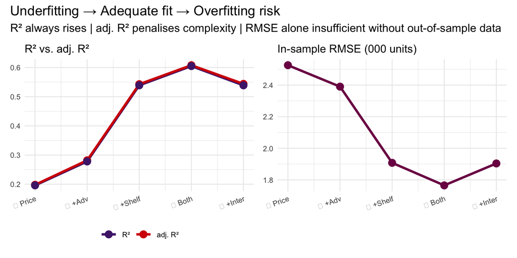

```r
fit_df <- bind_rows(
  get_regression_summaries(mod_baseline)  %>% mutate(k = 2, label = "① Price"),
  get_regression_summaries(mod_adv)       %>% mutate(k = 3, label = "② +Adv"),
  get_regression_summaries(mod_shelf)     %>% mutate(k = 4, label = "③ +Shelf"),
  get_regression_summaries(mod_full)      %>% mutate(k = 5, label = "④ Both"),
  get_regression_summaries(mod_int_shelf) %>% mutate(k = 6, label = "⑤ +Inter")
)

p_r2 <- fit_df %>%
  pivot_longer(c(r_squared, adj_r_squared),
               names_to = "metric", values_to = "val") %>%
  ggplot(aes(x = k, y = val, color = metric, group = metric)) +
  geom_line(linewidth = 1.1) + geom_point(size = 3) +
  scale_color_manual(values = c("r_squared"     = "#D50006",
                                "adj_r_squared" = "#502479"),
                     labels = c("R²", "adj. R²")) +
  scale_x_continuous(breaks = c(2,3,4,5,6), labels = fit_df$label) +
  labs(title = "R² vs. adj. R²", x = NULL, y = NULL, color = NULL) +
  theme_minimal(base_size = 9) +
  theme(axis.text.x = element_text(angle = 20, hjust = 1),
        legend.position = "bottom")

p_rmse <- fit_df %>%
  ggplot(aes(x = k, y = rmse)) +
  geom_line(color = "#7d0a52", linewidth = 1.1) +
  geom_point(color = "#7d0a52", size = 3) +
  scale_x_continuous(breaks = c(2,3,4,5,6), labels = fit_df$label) +
  labs(title = "In-sample RMSE (000 units)", x = NULL, y = NULL) +
  theme_minimal(base_size = 9) +
  theme(axis.text.x = element_text(angle = 20, hjust = 1))

(p_r2 + p_rmse) +
  plot_annotation(
    title    = "Underfitting → Adequate fit → Overfitting risk",
    subtitle = "R² always rises | adj. R² penalises complexity | RMSE alone insufficient without out-of-sample data"
  )
```

**ImportantThe fundamental tension**

**Underfitting** (models ①–②): Too simple — misses real patterns. Symptom: low adj. R², systematic residual patterns.

**Adequate fit** (model ④): Captures the main variation with interpretable, theory-grounded predictors and justified modelling assumptions.

**Overfitting risk** (model ⑤): Adds complexity without improving adj. R². In-sample fit looks fine; performance on new data degrades.

**Today we only see in-sample fit** — diagnosing overfitting requires new data or cross-validation (ER017).

> *“Discovery without overfit. The challenge of data science is to find real patterns — not to memorize the noise in your sample.”* — Taddy (2019), p. 8

## 8 Residual Diagnostics

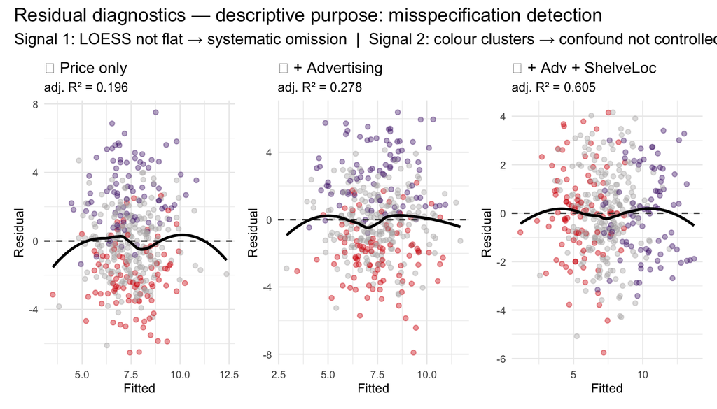

```r
pts_base <- augment(mod_baseline, data = tbl_carseats)
pts_adv2 <- augment(mod_adv,      data = tbl_carseats)
pts_full <- augment(mod_full,      data = tbl_carseats)

mk <- function(pts, title, r2) {
  pts %>%
    ggplot(aes(.fitted, .resid, color = ShelveLoc)) +
    geom_point(alpha = 0.4, size = 1.3) +
    geom_hline(yintercept = 0, linetype = "dashed", color = "#333") +
    geom_smooth(aes(group = 1), method = "loess", se = FALSE,
                color = "black", linewidth = 0.9) +
    scale_color_manual(values = col_shelf_resid,
                       guide = "none") +
    labs(title    = title,
         subtitle = paste0("adj. R² = ", round(r2, 3)),
         x = "Fitted", y = "Residual") +
    theme_minimal(base_size = 9)
}

(mk(pts_base, "① Price only",         summary(mod_baseline)$adj.r.squared) +
 mk(pts_adv2, "② + Advertising",      summary(mod_adv)$adj.r.squared)      +
 mk(pts_full, "④ + Adv + ShelveLoc",  summary(mod_full)$adj.r.squared)) +
  plot_annotation(
    title    = "Residual diagnostics — descriptive purpose: misspecification detection",
    subtitle = paste0(
      "Signal 1: LOESS not flat → systematic omission  |  ",
      "Signal 2: colour clusters → confound not controlled")
  )
```

**NoteHow to read these plots — two diagnostic signals**

**Signal 1 — LOESS trend:** A flat black line at zero = no systematic pattern remaining. A curved line = the model misses a systematic relationship.

**Signal 2 — colour clustering:** Colours randomly mixed = the coloured variable is controlled for. Colours clustered (purple above, red below) = the variable belongs in the model.

**① Price only:** LOESS bends; purple above zero, red below → ShelveLoc confounds, systematic omission.

**② + Advertising:** LOESS flatter but not flat; colour separation persists → ShelveLoc still missing.

**④ + Adv + ShelveLoc:** LOESS approximately flat; colours randomly mixed ✅ → main systematic variation absorbed. Remaining scatter: random noise + variables outside the dataset.

**What these plots do NOT check** in the descriptive setting: normality and homoskedasticity — those are needed for inference (PVA2), not for the descriptive conditional mean.

**Tip Instructor note — pointing out the signals**

Students scan the plots globally and often miss the two specific signals. Point explicitly:

*“In plot ①, where are the purple dots? Above zero. Where are the red ones? Below zero. That is not random — ShelveLoc systematically shifts the residuals.”*

*“In plot ④, the colour separation is gone. The model now accounts for shelf location — the residual is a cleaner signal.”*

## 9 Multicollinearity

```r
vif(mod_full)
```

```
                GVIF Df GVIF^(1/(2*Df))
Price       1.004420  1        1.002207
Advertising 1.005294  1        1.002644
ShelveLoc   1.005989  2        1.001494
```

```r
tb <- tbl_carseats %>%
  select(Price, Advertising, Income, Age, Population) %>%
  cor() %>% round(3) %>%
  as.data.frame() %>% rownames_to_column("Variable") %>%
  gt()
tb
```

| Variable | Price | Advertising | Income | Age | Population |
| --- | --- | --- | --- | --- | --- |
| Price | 1.000 | 0.045 | -0.057 | -0.102 | -0.012 |
| Advertising | 0.045 | 1.000 | 0.059 | -0.005 | 0.266 |
| Income | -0.057 | 0.059 | 1.000 | -0.005 | -0.008 |
| Age | -0.102 | -0.005 | -0.005 | 1.000 | -0.043 |
| Population | -0.012 | 0.266 | -0.008 | -0.043 | 1.000 |

**Show code: table formatting**

```r
tb %>%
  fmt_number(columns = -Variable, decimals = 3) %>%
  tab_options(table.font.size = "12px") %>%
  tab_header("Correlation matrix — numeric regressors")
```

Correlation matrix — numeric regressors

| Variable | Price | Advertising | Income | Age | Population |
| --- | --- | --- | --- | --- | --- |
| Price | 1.000 | 0.045 | −0.057 | −0.102 | −0.012 |
| Advertising | 0.045 | 1.000 | 0.059 | −0.005 | 0.266 |
| Income | −0.057 | 0.059 | 1.000 | −0.005 | −0.008 |
| Age | −0.102 | −0.005 | −0.005 | 1.000 | −0.043 |
| Population | −0.012 | 0.266 | −0.008 | −0.043 | 1.000 |

**NoteMulticollinearity: descriptive vs. inferential impact**

|  | Descriptive (today) | Stochastic / inference (PVA2) |
| --- | --- | --- |
| **Fitted values $\hat{y}_i$** | Unaffected | Unaffected |
| **Individual coefficients** | Partial effects unreliable when regressors correlated | Unbiased but high variance → wide CIs |
| **Diagnosis** | Correlation matrix, VIF | VIF, condition number |
| **Threshold** | \|r\| > 0.8 between regressors: caution | VIF > 5: problematic |

For model ④: all VIFs are low — no multicollinearity concern.

## 10 Performance Scores → Bridge to Lab 3

```r
store_scored <- mod_full %>%
  get_regression_points() %>%
  mutate(performance_gap = residual) %>%
  arrange(performance_gap)

tb <- store_scored %>%
  head(5) %>%
  select(ID, Sales, Sales_hat, residual) %>%
  gt()
```

**Show code: table formatting**

```r
tb %>%
  fmt_number(columns = c(Sales, Sales_hat, residual), decimals = 2) %>%
  tab_style(style = cell_fill(color = "#fff0f0"), locations = cells_body()) %>%
  tab_options(table.font.size = "13px") %>%
  tab_header("Top 5 Underperformers — strongest negative residuals")
```

Top 5 Underperformers — strongest negative residuals

| ID | Sales | Sales_hat | residual |
| --- | --- | --- | --- |
| 51 | 1.42 | 7.17 | −5.75 |
| 107 | 0.16 | 5.24 | −5.08 |
| 210 | 3.02 | 7.45 | −4.43 |
| 45 | 4.16 | 8.45 | −4.29 |
| 101 | 4.11 | 8.35 | −4.24 |

```r
gg <- store_scored %>%
  ggplot(aes(x = Sales_hat, y = performance_gap,
             color = performance_gap < -2)) +
  geom_point(alpha = 0.6, size = 1.8) +
  geom_hline(yintercept = 0, color = "#D50006",
             linewidth = 1.1, linetype = "dashed") +
  geom_hline(yintercept = c(-2, 2), color = "#686868",
             linewidth = 0.5, linetype = "dotted")
```

**Show code: labels & theme**

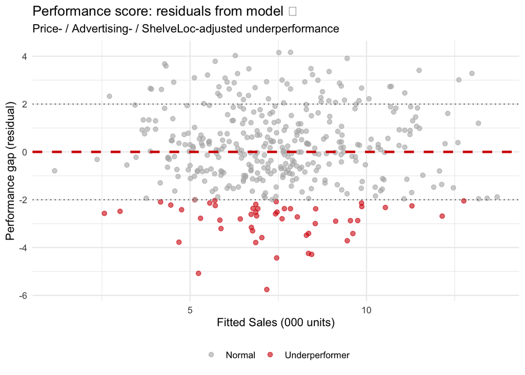

```r
gg +
  scale_color_manual(values  = c("FALSE" = "#b3b2b2", "TRUE" = "#D50006"),
                     labels  = c("Normal", "Underperformer")) +
  labs(title    = "Performance score: residuals from model ④",
       subtitle = "Price- / Advertising- / ShelveLoc-adjusted underperformance",
       x = "Fitted Sales (000 units)",
       y = "Performance gap (residual)",
       color = NULL) +
  theme_minimal(base_size = 11) +
  theme(legend.position = "bottom")
```

**Tip Instructor note — handover to Lab 3**

*“This is the output of the demo: a performance score for every store, adjusted for price, advertising budget, and shelf location. A store with a strongly negative residual sells less than comparable stores under the same conditions — that is the underperformer signal.”*

*“In Lab 3 you will rank these stores, look at their characteristics, and write the Managerial Memo. Open `PVA1_Lab3_PerformanceMining.qmd`.”*

## 11 What We Learned: Four Models at a Glance

Now that we have worked through each model step by step, here is the comparison that motivated the sequence:

```r
tb <- bind_rows(
  get_regression_summaries(mod_adv)       %>% mutate(Model = "Price + Advertising",       k = 3),
  get_regression_summaries(mod_int_adv)   %>% mutate(Model = "Price × Advertising",       k = 4),
  get_regression_summaries(mod_shelf)     %>% mutate(Model = "Price + ShelveLoc",          k = 4),
  get_regression_summaries(mod_int_shelf) %>% mutate(Model = "Price × ShelveLoc",          k = 6)
) %>%
  select(Model, k, r_squared, adj_r_squared, rmse) %>%
  gt()
```

**Show code: table formatting**

```r
tb %>%
  fmt_number(columns = c(r_squared, adj_r_squared, rmse), decimals = 3) %>%
  tab_style(style = cell_fill(color = "#f0fff0"),
            locations = cells_body(rows = str_detect(Model, "ShelveLoc"))) %>%
  tab_style(style = cell_fill(color = "#fff0f0"),
            locations = cells_body(rows = str_detect(Model, "Advertising"))) %>%
  tab_options(table.font.size = "13px") %>%
  tab_header(
    "Four two-variable models — why we started with ShelveLoc",
    subtitle = paste0(
      "Green = ShelveLoc (adj. R² ≈ 0.54)  |  ",
      "Red = Advertising (adj. R² ≈ 0.28)  |  ",
      "Interaction adds nothing in either case")
  )
```

Four two-variable models — why we started with ShelveLoc

Green = ShelveLoc (adj. R² ≈ 0.54) | Red = Advertising (adj. R² ≈ 0.28) | Interaction adds nothing in either case

| Model | k | r_squared | adj_r_squared | rmse |
| --- | --- | --- | --- | --- |
| Price + Advertising | 3 | 0.282 | 0.278 | 2.390 |
| Price × Advertising | 4 | 0.283 | 0.277 | 2.389 |
| Price + ShelveLoc | 4 | 0.543 | 0.539 | 1.908 |
| Price × ShelveLoc | 6 | 0.544 | 0.539 | 1.904 |

**NoteThe numbers explain the sequence**

**ShelveLoc** alone explains nearly twice as much variance as Advertising — and adding an interaction term changes nothing (adj. R² identical at 0.539). That is why we started with ShelveLoc and chose the parallel-slopes model: the data guided the decision, not convention.

## 12 Summary

| Model | r_squared | adj_r_squared | rmse |
| --- | --- | --- | --- |
| ① Sales ~ Price | 0.1980 | 0.1960 | 2.5260 |
| ② + ShelveLoc (parallel) | 0.5430 | 0.5390 | 1.9076 |
| ③ + Advertising + ShelveLoc ← selected | 0.6080 | 0.6050 | 1.7649 |

**ImportantKey concepts established in this demo**

1. **Descriptive Regression Notation:** $b_j$ / $e_i$ (descriptive) — distinguished from $\hat\beta_j$ / $\varepsilon_i$ (stochastic, Session 3)
2. **Orientation table first:** empirical adj. R² comparison guides model-building sequence before any individual coefficient is examined
3. **`geom_smooth()` reveals the interaction model** implicitly — always check whether non-parallel slopes are warranted
4. **Occam’s Razor operationalised by adj. R²:** Carseats → parallel slopes (adj. R² unchanged); UT Austin → interaction (adj. R² improves)
5. **Geometry:** line (k=1) → plane (k=2 numeric) → parallel planes (+ categorical, no interaction) → tilted planes (+ interaction)
6. **Partial effects** = partial derivatives = ceteris paribus — descriptive, not causal
7. **Confounding and control variables:** ShelveLoc biases the Price coefficient; controlling for it corrects the OVB (visible numerically)
8. **Centering:** makes $b_0$ meaningful as predicted outcome at mean $\mathbf{x}$
9. **Simpson’s Paradox:** aggregate slope can differ from or reverse the partial slope — always ask what is being controlled for
10. **adj. R² for model comparison**, eyeball test (Occam), forward specification
11. **Residual diagnostics (descriptive):** two signals — LOESS trend (misspecification) and colour clustering (uncontrolled confound)
12. **Multicollinearity:** affects individual coefficients (not fitted values); VIF > 5 as warning threshold

## References

Taddy, Matt. 2019. *Business Data Science: Combining Machine Learning and Economics to Optimize, Automate, and Accelerate Business Decisions*. 1 Edition. New York: McGraw-Hill Education.